# HW_3

Andrei Kravets

2024-01-12

# Data Import

```r
data <- read_tsv("HW_data.tsv")
#summary(data)
```

# Task 1

Каким образом вы будете оценивать физическую активность респондентов? Есть ли у вас предварительные предположения относительно того, каким образом выбранный вами пока- затель может быть ассоциирован с гликированным гемоглобином?

Для оценки физической активности воспользуемся шкалой MET - https://media.hypersites.com/clients/1235/filemanager/MHC/METs.pdf [верх первой страницы] С учётом того, что использование велосипеда будет приравниваться к Moderate Activities.

Моя шкала активности будет Total_MET_minutes_per_week

По сути для кажого вида активности расчёт будет следующим: [коэф активности] * [есть ли это активность, пр. PAQ605] * [дней в неделю с такой активностью] * [кол-во минут в день такой активности (конечно, в те дни, когда сама активность была)]

```r
data_MET = data %>%
    mutate(
      # Define MET values for each activity type
      MET_vigorous_work = 8 * PAQ605 * PAD615 * PAQ610,
      MET_moderate_work = 4 * PAQ620 * PAD630 * PAQ625,
      MET_walk_bike = 4 * PAQ635 * PAD645 * PAQ640,
      MET_vigorous_recreation = 8 * PAQ650 * PAD660 * PAQ655,
      MET_moderate_recreation = 4 * PAQ665 * PAD675 * PAQ670,
      MET_sedentary = 1.5 * PAD680,

      # Calculate total MET-minutes per week
      Total_MET_minutes_per_week = MET_vigorous_work +
                                   MET_moderate_work +
                                   MET_walk_bike +
                                   MET_vigorous_recreation +
                                   MET_moderate_recreation -
                                   MET_sedentary
    )
```

## Отбор колонок для EDA

SEQN, RIAGENDR, RIDAGEYR, RIDRETH3, DMDEDUC2 [educational], INDFMIN2 [income], SMQ040 [smoking], LBXGH - Glycohemoglobin (%) [hemoglobin]

```r
data_MET_pre_final = data_MET %>%
    mutate(Comorbidities = if_else(
        MCQ010 == 1 | MCQ035 == 1 | MCQ160C == 1 | MCQ160B == 1 |
        MCQ160E == 1 | MCQ160F == 1 | MCQ160M == 1 | MCQ170M == 1 |
        MCQ160O == 1 | MCQ220 == 1,
        1, 0)) %>%
    select(SEQN, RIAGENDR, RIDAGEYR, RIDRETH3, DMDEDUC2, INDFMIN2, SMQ040,
           LBXGH, Comorbidities, Total_MET_minutes_per_week)
```

Factors: RIAGENDR, RIDRETH3, DMDEDUC2, INDFMIN2, Comorbidities, SMQ040 Numeric: LBXGH, Total_MET_minutes_per_week

Привем факторы и поменяем значения на именные. На всякий случай гликолиз к численному типу приведем.

```r
data_MET_final = data_MET_pre_final %>% mutate(
    Gender = factor(RIAGENDR, levels = c(1, 2),
                    labels = c("Male", "Female")),
    Race = factor(RIDRETH3,  levels = c(1, 2, 3, 4, 6, 7),
                       labels = c("Mexican American",
                                  "Other Hispanic",
                                  "White",
                                  "Black",
                                  "Asian",
                                  "Other Race")),
    Education = factor(DMDEDUC2, levels = c(1, 2, 3, 4, 5),
                       labels = c("< 9th grade",
                                  "9-11th grade",
                                  "High School",
                                  "College UnderGrad",
                                  "College Grad")),
    Income_Level = factor(INDFMIN2,
                         levels = 1:12,
                         labels = c(
                           "Up to 4,999$",
                           "5k-9,999$",
                           "10k-14,999$",
                           "15k-19,999$",
                           "20k-24,999$",
                           "25k-34,999$",
                           "35k-44,999$",
                           "45k-54,999$",
                           "55k-64,999$",
                           "65k-74,999$",
                           "75k-99,999$",
                           "100k+"
                         )),
    Comorbidities = factor(Comorbidities, levels = c(0, 1),
                           labels = c("No", "Yes")),
    Smoking = factor(SMQ040, levels = 1:3,
                     labels = c("EveryDay", "SomeDay", "Not at all")),
    GlyHemo = as.numeric(LBXGH)) %>%
  select(Gender, Race, Education, Income_Level, Comorbidities,
         Smoking, GlyHemo, Total_MET_minutes_per_week)
```

```r
head(data_MET_final)
```

```
## # A tibble: 6 × 8
##   Gender Race  Education         Income_Level Comorbidities Smoking    GlyHemo
##   <fct>  <fct> <fct>             <fct>        <fct>         <fct>        <dbl>
## 1 Female White College UnderGrad 15k-19,999$  Yes           Not at all      62
## 2 Male   Black College Grad      100k+        Yes           Not at all      56
## 3 Male   White High School       35k-44,999$  No            EveryDay        52
## 4 Male   White College UnderGrad 20k-24,999$  No            Not at all      58
## 5 Male   Black High School       100k+        Yes           Not at all      52
## 6 Male   Asian High School       100k+        No            Not at all      53
## # ℹ 1 more variable: Total_MET_minutes_per_week <dbl>
```

# Task 3

Проведите необходимый эксплораторный анализ перед оценкой модели.

Здесь начнём с 3-го пункта, чтобы посмотреть на наши данные, а потом пойдем модель делать :)

```r
numeric_cols <- select_if(data_MET_final, is.numeric)
factor_cols <- select_if(data_MET_final, is.factor)
```

```r
tbl_summary(
  data_MET_final,
  type = list(all_continuous() ~ "continuous2"),
  statistic = list(
    all_continuous() ~ c("{mean} ({sd})", "{median} ({p25}-{p75})", "{min}-{max}")
  )) %>%
  modify_footnote(everything() ~ NA) %>%
  bold_labels()
```

| **Characteristic** | **N = 916** |
| --- | --- |
| Gender |  |
| Male | 539 (59%) |
| Female | 377 (41%) |
| Race |  |
| Mexican American | 101 (11%) |
| Other Hispanic | 75 (8.2%) |
| White | 463 (51%) |
| Black | 175 (19%) |
| Asian | 78 (8.5%) |
| Other Race | 24 (2.6%) |
| Education |  |
| < 9th grade | 54 (5.9%) |
| 9-11th grade | 119 (13%) |
| High School | 203 (22%) |
| College UnderGrad | 297 (32%) |
| College Grad | 243 (27%) |
| Income_Level |  |
| Up to 4,999$ | 23 (2.5%) |
| 5k-9,999$ | 36 (3.9%) |
| 10k-14,999$ | 69 (7.5%) |
| 15k-19,999$ | 78 (8.5%) |
| 20k-24,999$ | 73 (8.0%) |
| 25k-34,999$ | 104 (11%) |
| 35k-44,999$ | 100 (11%) |
| 45k-54,999$ | 78 (8.5%) |
| 55k-64,999$ | 54 (5.9%) |
| 65k-74,999$ | 49 (5.3%) |
| 75k-99,999$ | 73 (8.0%) |
| 100k+ | 179 (20%) |
| Comorbidities | 374 (41%) |
| Smoking |  |
| EveryDay | 133 (15%) |
| SomeDay | 31 (3.4%) |
| Not at all | 752 (82%) |
| GlyHemo |  |
| Mean (SD) | 52 (18) |
| Median (Q1-Q3) | 55 (52-58) |
| Min-Max | 5-139 |
| Total_MET_minutes_per_week |  |
| Mean (SD) | 2,349 (5,120) |
| Median (Q1-Q3) | 300 (-515-2,880) |
| Min-Max | -14,999-33,590 |

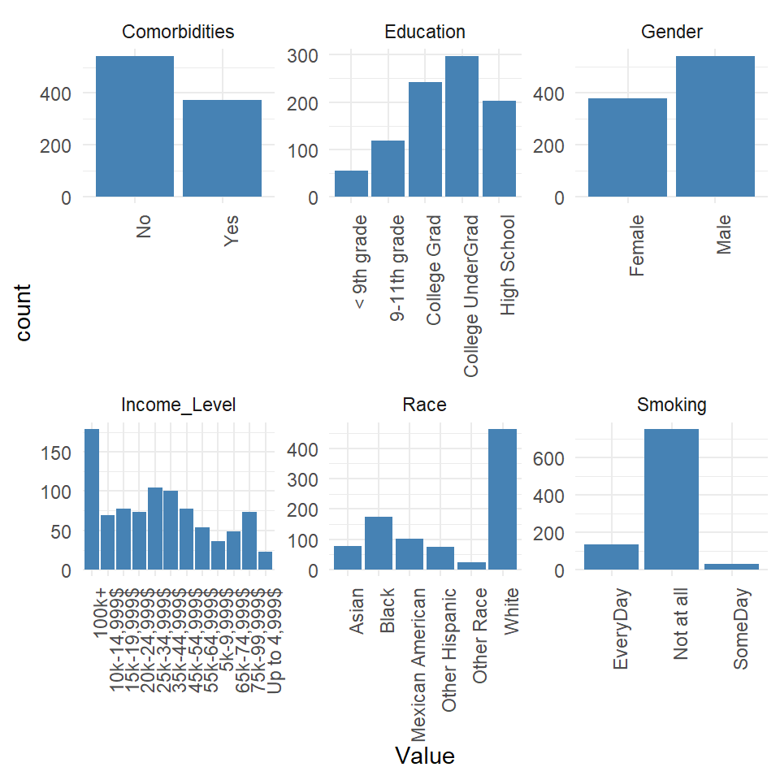

```r
factor_cols %>%
  gather(key = "Variable", value = "Value") %>%
  ggplot(aes(x = Value)) +
  geom_bar(fill = "steelblue") +
  facet_wrap(~ Variable, scales = "free") +
  theme_minimal() +
  theme(
    axis.text.x = element_text(angle = 90, hjust = 1)
  )
```

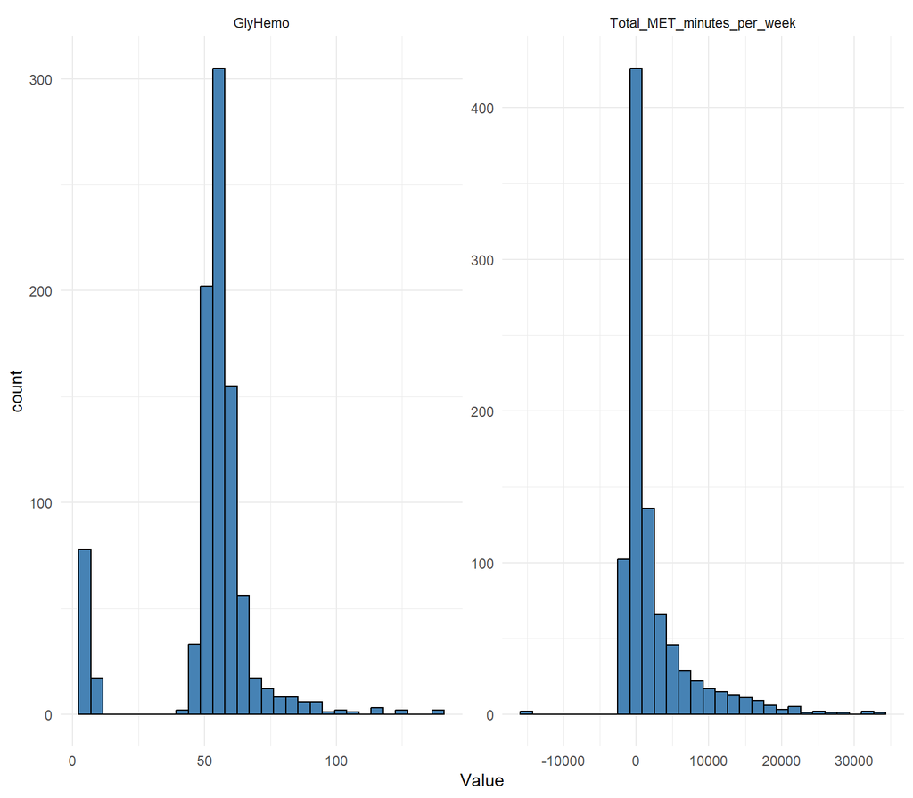

```r
numeric_cols %>%
  gather(key = "Variable", value = "Value") %>%
  ggplot(aes(x = Value)) +
  geom_histogram(bins = 30, fill = "steelblue", color = "black") +
  facet_wrap(~ Variable, scales = "free") +
  theme_minimal()
```

Видим, что у нас есть “выбросы” и по GlyHemo и по Total_MET_minutes_per_week. Например, у нас есть много аутлайеров по кол-во гликолизированного гемоглобина (GlyHemo = 0) - возможно это связано с очень крутыми спорстменами и/или специфичным метаболизмом какой-нибудь группы людей (e.g. по профессии и т.п.).

Все-таки отфильтруем выбросы используя 1.5 IQR метод для обоих колонок, чтобы они нам не мешали оценивать средний эффект:

```r
data_MET_final <- data_MET_final %>%
  filter(GlyHemo < quantile(GlyHemo, 0.75, na.rm = TRUE) + 1.5 * IQR(GlyHemo, na.rm = TRUE) &
         GlyHemo > quantile(GlyHemo, 0.25, na.rm = TRUE) - 1.5 * IQR(GlyHemo, na.rm = TRUE),
         Total_MET_minutes_per_week < quantile(Total_MET_minutes_per_week, 0.75, na.rm = TRUE) + 1.5 * IQR(Total_MET_minutes_per_week, na.rm = TRUE) &
         Total_MET_minutes_per_week > quantile(Total_MET_minutes_per_week, 0.25, na.rm = TRUE) - 1.5 * IQR(Total_MET_minutes_per_week, na.rm = TRUE)
          )

numeric_cols <- select_if(data_MET_final, is.numeric)
```

Вычистили аутлайеры, посмотрим на распределения ещё раз:

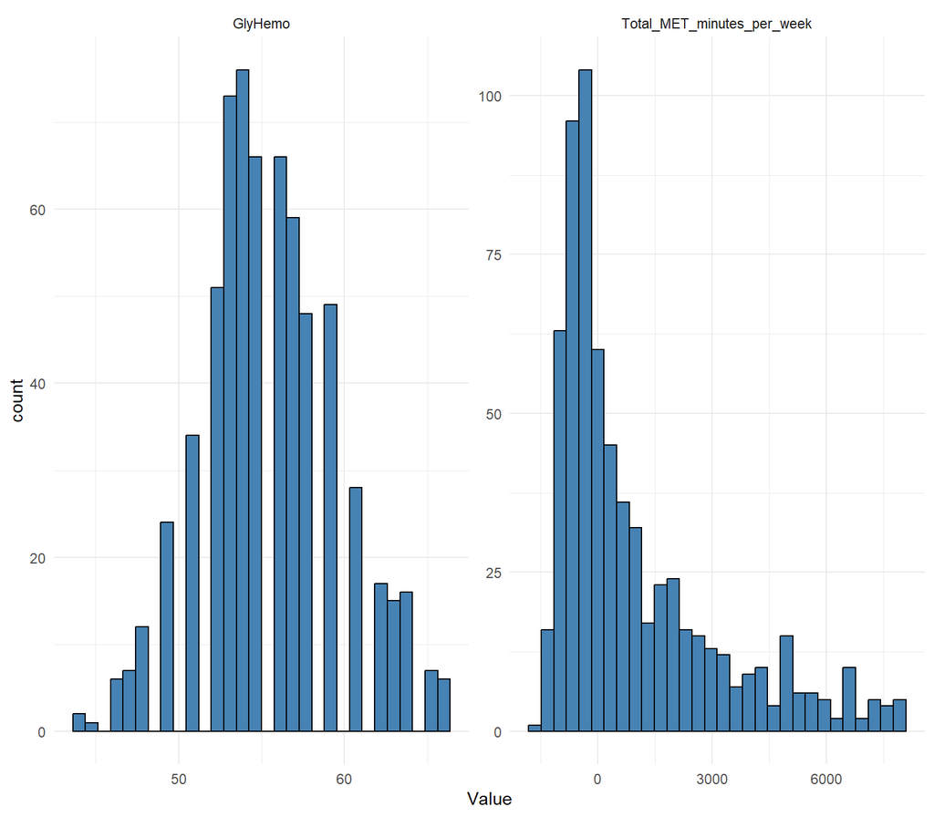

```r
numeric_cols %>%
  gather(key = "Variable", value = "Value") %>%
  ggplot(aes(x = Value)) +
  geom_histogram(bins = 30, fill = "steelblue", color = "black") +
  facet_wrap(~ Variable, scales = "free") +
  theme_minimal()
```

Видим, что все-таки физическая активность у нас имеет не очень нормальное распределение, а более негативно-биномиальное-эспоненциальное. Давайте прологарифмируем эту метрику и посмотрим ещё раз. Правда, т.к. у нас есть отрицательные значения, то нам понадобится log1p + offset шкалирование. И отфильтруем данные от супер изначально отрицательных значений.

```r
data_MET_final <- data_MET_final %>%
  mutate(Total_MET_minutes_per_week_log = log1p(Total_MET_minutes_per_week
                                                + abs(min(Total_MET_minutes_per_week)))
          ) %>%
  filter(Total_MET_minutes_per_week_log > 2.5)

numeric_cols <- select_if(data_MET_final, is.numeric)
```

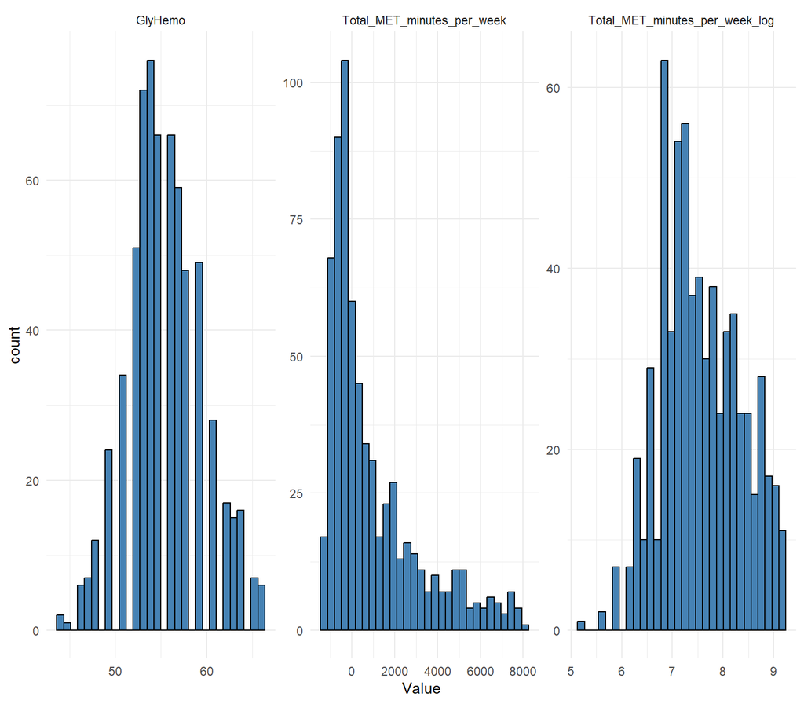

```r
numeric_cols %>%
  gather(key = "Variable", value = "Value") %>%
  ggplot(aes(x = Value)) +
  geom_histogram(bins = 30, fill = "steelblue", color = "black") +
  facet_wrap(~ Variable, scales = "free") +
  theme_minimal()
```

Нас интересуют средний и правый графики. Видим, что распределение физической активности стало гораздо лучше. Дальше в модели будем использовать иммено логарифм.

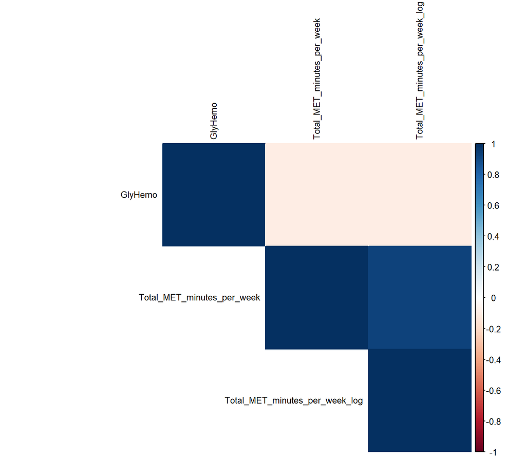

```r
# Correlation matrix
cor_matrix <- cor(numeric_cols, use = "complete.obs")

# Visualize correlation matrix
library(corrplot)
corrplot(cor_matrix, method = "color", type = "upper", tl.col = "black", tl.cex = 0.8)
```

“В лоб” наши exposure (и в логарифме и без) & outcome не особо коррелируют между собой. Интересно, что покажет анализ лин. регрессий.

Боксплоты на числовых колонок:

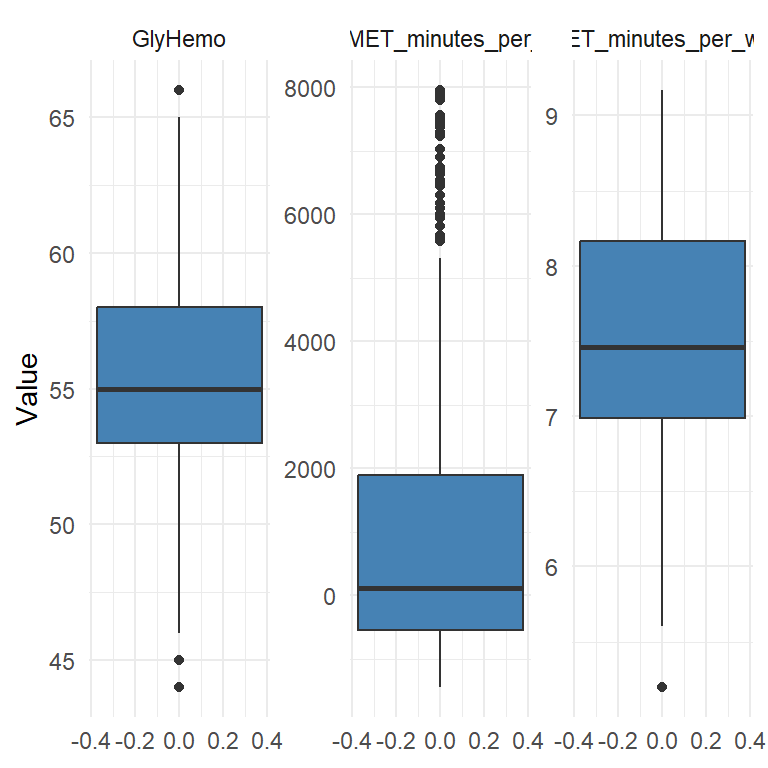

```r
# Boxplot to identify outliers
numeric_cols %>%
  gather(key = "Variable", value = "Value") %>%
  ggplot(aes(y = Value)) +
  geom_boxplot(fill = "steelblue") +
  facet_wrap(~ Variable, scales = "free") +
  theme_minimal()
```

```r
# Calculate Z-scores
numeric_cols %>%
  mutate_all(~ (.-mean(.)) / sd(.)) %>%
  filter_if(is.numeric, any_vars(abs(.) > 3))
```

```
## # A tibble: 12 × 3
##    GlyHemo Total_MET_minutes_per_week Total_MET_minutes_per_week_log
##      <dbl>                      <dbl>                          <dbl>
##  1   0.613                      -1.13                          -3.02
##  2   0.122                       3.02                           1.99
##  3   0.859                       3.06                           2.00
##  4  -1.11                        3.00                           1.98
##  5   0.122                       3.23                           2.05
##  6   1.84                        3.26                           2.06
##  7  -0.614                       3.09                           2.01
##  8  -0.369                       3.20                           2.04
##  9  -0.369                       3.27                           2.06
## 10   1.35                        3.03                           1.99
## 11   0.368                       3.09                           2.01
## 12  -0.860                       3.22                           2.05
```

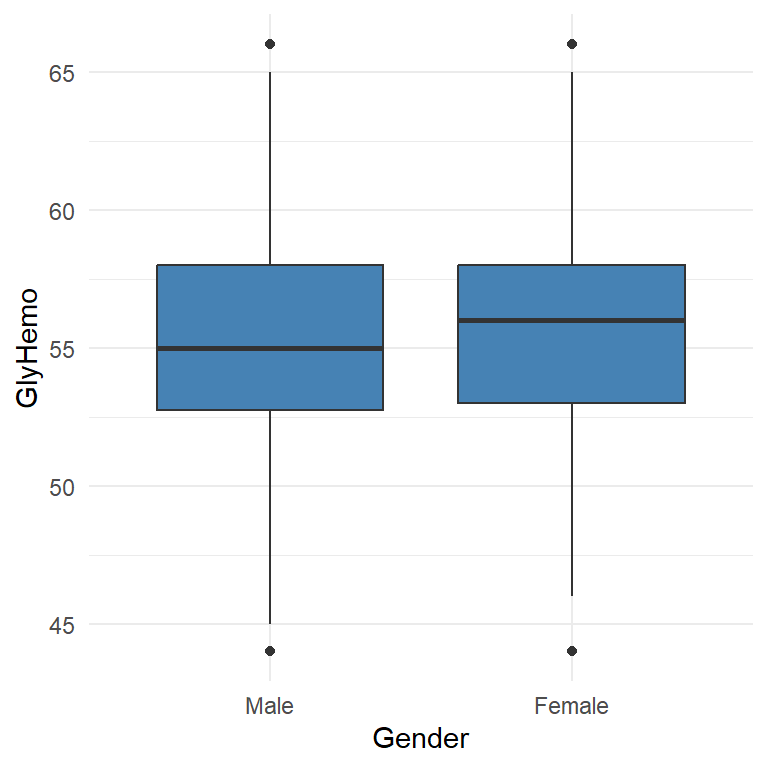

```r
# Boxplot to identify outliers
data_MET_final %>%
  ggplot(aes(y = GlyHemo, x=Gender)) +
  geom_boxplot(fill = "steelblue") +
  theme_minimal()
```

# Task 2

Ковариаты для каких показателей вы включите в модель для коррекции эффекта физической активности в отношении гликированного гемоглобина? Каким образом вы будете их оцени- вать по имеющимся данным?

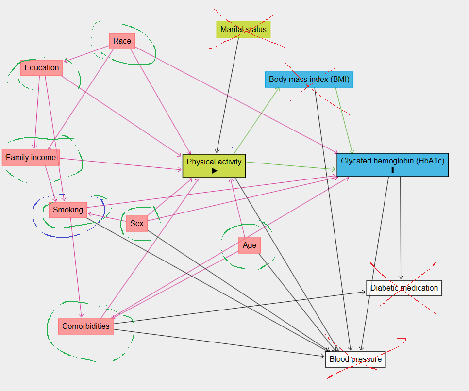

Вопрос вызывает только одна вещь - Курение! Отсутствие стрелки в ДАГе является сильным заявлением отсутствия связи. На мой взгляд, курение не только связано с другими факторами, пр. comorbidities, но и должно быть напрямую связано с Physical Activity. Как курящий человек, могу сказать, что курильщикам сложнее зачастую заниматься спортом, т.к. отдышка и т.д., курильщикам больше нужно времени на восстановление после физических активностей.

Т.о. субъективно пришёл к выводу, что курение нужно оставить в модели, хоть в изначальном ДАГе причин для его включения не особо есть.

# Task 4

Оцените модель для зависимости гликированного гемоглобина от выбранного вами показа- теля физической активности без ковариат и с ними. Проведите необходимую диагностику этих моделей – требует ли что-либо коррекции и почему? В случае необходимости коррек- ции по результатам диагностики сделайте ее.

## Модель без дополнительных эффектов

```r
formula_1 = formula(GlyHemo ~ Total_MET_minutes_per_week_log)

model.matrix(formula_1, data_MET_final) %>%
  head()
```

```
##   (Intercept) Total_MET_minutes_per_week_log
## 1           1                       7.611348
## 2           1                       8.830689
## 3           1                       8.694670
## 4           1                       6.898715
## 5           1                       6.898715
## 6           1                       7.065613
```

```r
first_fit <- lm(formula_1, data_MET_final)
print(first_fit)
```

```
##
## Call:
## lm(formula = formula_1, data = data_MET_final)
##
## Coefficients:
##                    (Intercept)  Total_MET_minutes_per_week_log
##                        59.1028                         -0.4765
```

```r
summary(first_fit)
```

```
##
## Call:
## lm(formula = formula_1, data = data_MET_final)
##
## Residuals:
##      Min       1Q   Median       3Q      Max
## -11.7007  -2.6455  -0.2753   2.3239  10.4447
##
## Coefficients:
##                                Estimate Std. Error t value Pr(>|t|)
## (Intercept)                     59.1028     1.5381  38.426   <2e-16 ***
## Total_MET_minutes_per_week_log  -0.4765     0.2024  -2.354   0.0189 *
## ---
## Signif. codes:  0 '***' 0.001 '**' 0.01 '*' 0.05 '.' 0.1 ' ' 1
##
## Residual standard error: 4.06 on 660 degrees of freedom
## Multiple R-squared:  0.008325,   Adjusted R-squared:  0.006822
## F-statistic:  5.54 on 1 and 660 DF,  p-value: 0.01887
```

```r
broom::tidy(first_fit, conf.int = TRUE)
```

```
## # A tibble: 2 × 7
##   term                 estimate std.error statistic   p.value conf.low conf.high
##   <chr>                   <dbl>     <dbl>     <dbl>     <dbl>    <dbl>     <dbl>
## 1 (Intercept)            59.1       1.54      38.4  1.64e-170   56.1     62.1
## 2 Total_MET_minutes_p…   -0.477     0.202     -2.35 1.89e-  2   -0.874   -0.0790
```

## Модель с дополнительными эффектами

```r
formula_all = formula(GlyHemo ~ Total_MET_minutes_per_week_log + Smoking +
                        Education + Comorbidities +
          Income_Level + Education + Race + Gender)
```

```r
all_fit <- lm(formula_all, data_MET_final)
print(all_fit)
```

```
##
## Call:
## lm(formula = formula_all, data = data_MET_final)
##
## Coefficients:
##                    (Intercept)  Total_MET_minutes_per_week_log
##                        56.5934                         -0.3668
##                 SmokingSomeDay               SmokingNot at all
##                         0.3555                          1.1370
##          Education9-11th grade            EducationHigh School
##                        -2.1657                         -2.2975
##     EducationCollege UnderGrad           EducationCollege Grad
##                        -2.3076                         -3.4552
##               ComorbiditiesYes           Income_Level5k-9,999$
##                         0.6466                          1.5706
##        Income_Level10k-14,999$         Income_Level15k-19,999$
##                         2.8016                          2.7836
##        Income_Level20k-24,999$         Income_Level25k-34,999$
##                         2.5216                          2.9327
##        Income_Level35k-44,999$         Income_Level45k-54,999$
##                         2.0655                          2.7636
##        Income_Level55k-64,999$         Income_Level65k-74,999$
##                         2.4481                          2.6791
##        Income_Level75k-99,999$               Income_Level100k+
##                         1.6961                          2.4924
##             RaceOther Hispanic                       RaceWhite
##                         0.5860                         -0.2459
##                      RaceBlack                       RaceAsian
##                         1.4005                          1.6065
##                 RaceOther Race                    GenderFemale
##                        -0.4721                          0.5617
```

```r
summary(all_fit)
```

```
##
## Call:
## lm(formula = formula_all, data = data_MET_final)
##
## Residuals:
##      Min       1Q   Median       3Q      Max
## -11.4235  -2.3580  -0.3896   2.3230  10.7295
##
## Coefficients:
##                                Estimate Std. Error t value Pr(>|t|)
## (Intercept)                     56.5934     1.9006  29.777  < 2e-16 ***
## Total_MET_minutes_per_week_log  -0.3668     0.2070  -1.772  0.07688 .
## SmokingSomeDay                   0.3555     0.9563   0.372  0.71021
## SmokingNot at all                1.1370     0.4802   2.368  0.01819 *
## Education9-11th grade           -2.1657     0.8165  -2.652  0.00819 **
## EducationHigh School            -2.2975     0.7944  -2.892  0.00396 **
## EducationCollege UnderGrad      -2.3076     0.7809  -2.955  0.00324 **
## EducationCollege Grad           -3.4552     0.8177  -4.225 2.73e-05 ***
## ComorbiditiesYes                 0.6466     0.3327   1.944  0.05238 .
## Income_Level5k-9,999$            1.5706     1.2261   1.281  0.20065
## Income_Level10k-14,999$          2.8016     1.1020   2.542  0.01125 *
## Income_Level15k-19,999$          2.7836     1.0778   2.583  0.01002 *
## Income_Level20k-24,999$          2.5216     1.0956   2.301  0.02169 *
## Income_Level25k-34,999$          2.9327     1.0575   2.773  0.00571 **
## Income_Level35k-44,999$          2.0655     1.0491   1.969  0.04940 *
## Income_Level45k-54,999$          2.7636     1.0841   2.549  0.01103 *
## Income_Level55k-64,999$          2.4481     1.1638   2.104  0.03581 *
## Income_Level65k-74,999$          2.6791     1.1617   2.306  0.02142 *
## Income_Level75k-99,999$          1.6961     1.0899   1.556  0.12014
## Income_Level100k+                2.4924     1.0244   2.433  0.01525 *
## RaceOther Hispanic               0.5860     0.7457   0.786  0.43226
## RaceWhite                       -0.2459     0.5911  -0.416  0.67751
## RaceBlack                        1.4005     0.6435   2.176  0.02989 *
## RaceAsian                        1.6065     0.7571   2.122  0.03423 *
## RaceOther Race                  -0.4721     1.0683  -0.442  0.65873
## GenderFemale                     0.5617     0.3276   1.715  0.08690 .
## ---
## Signif. codes:  0 '***' 0.001 '**' 0.01 '*' 0.05 '.' 0.1 ' ' 1
##
## Residual standard error: 3.915 on 636 degrees of freedom
## Multiple R-squared:  0.1115, Adjusted R-squared:  0.07658
## F-statistic: 3.193 on 25 and 636 DF,  p-value: 3.948e-07
```

```r
broom::tidy(all_fit, conf.int = TRUE)
```

```
## # A tibble: 26 × 7
##    term                estimate std.error statistic   p.value conf.low conf.high
##    <chr>                  <dbl>     <dbl>     <dbl>     <dbl>    <dbl>     <dbl>
##  1 (Intercept)           56.6       1.90     29.8   1.11e-122 52.9       60.3
##  2 Total_MET_minutes_…   -0.367     0.207    -1.77  7.69e-  2 -0.773      0.0397
##  3 SmokingSomeDay         0.356     0.956     0.372 7.10e-  1 -1.52       2.23
##  4 SmokingNot at all      1.14      0.480     2.37  1.82e-  2  0.194      2.08
##  5 Education9-11th gr…   -2.17      0.817    -2.65  8.19e-  3 -3.77      -0.562
##  6 EducationHigh Scho…   -2.30      0.794    -2.89  3.96e-  3 -3.86      -0.738
##  7 EducationCollege U…   -2.31      0.781    -2.95  3.24e-  3 -3.84      -0.774
##  8 EducationCollege G…   -3.46      0.818    -4.23  2.73e-  5 -5.06      -1.85
##  9 ComorbiditiesYes       0.647     0.333     1.94  5.24e-  2 -0.00668    1.30
## 10 Income_Level5k-9,9…    1.57      1.23      1.28  2.01e-  1 -0.837      3.98
## # ℹ 16 more rows
```

```r
broom::augment(all_fit) %>% head()
```

```
## # A tibble: 6 × 14
##   GlyHemo Total_MET_minutes_per_w…¹ Smoking Education Comorbidities Income_Level
##     <dbl>                     <dbl> <fct>   <fct>     <fct>         <fct>
## 1      62                      7.61 Not at… College … Yes           15k-19,999$
## 2      56                      8.83 Not at… College … Yes           100k+
## 3      58                      8.69 Not at… College … No            20k-24,999$
## 4      53                      6.90 Not at… High Sch… No            100k+
## 5      64                      6.90 Not at… College … Yes           75k-99,999$
## 6      48                      7.07 Not at… College … No            100k+
## # ℹ abbreviated name: ¹Total_MET_minutes_per_week_log
## # ℹ 8 more variables: Race <fct>, Gender <fct>, .fitted <dbl>, .resid <dbl>,
## #   .hat <dbl>, .sigma <dbl>, .cooksd <dbl>, .std.resid <dbl>
```

## Диагностика модели

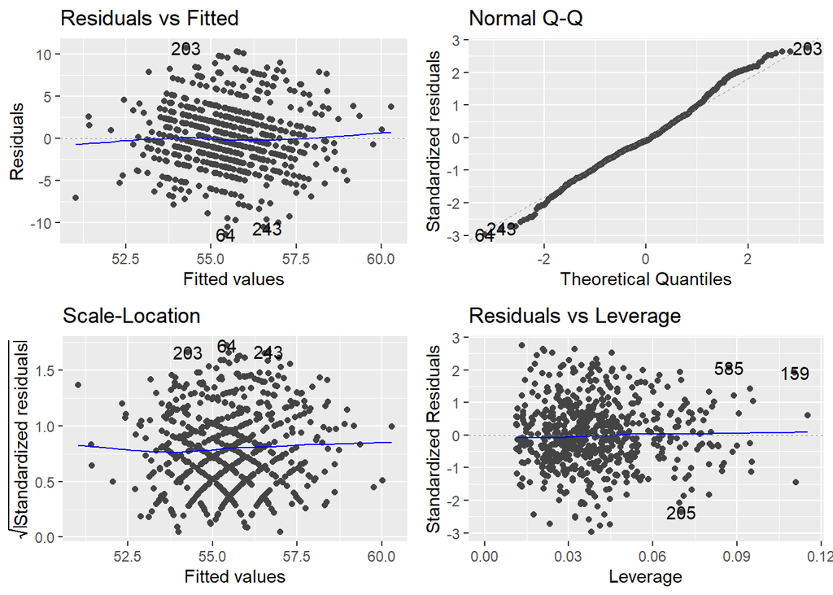

```r
autoplot(all_fit)
```

Вообще по диагностике все выглядит хорошо. Меня только смущает “сетчатая” структура на графике Scale-Location. Это очень странно, конечно.

# Task 5 & 6

Представьте результаты оценки модели без ковариат и с ковариатами в виде точечной и интервальной оценки эффекта физической активности. Дайте им словесную интерпретацию. Какие выводы мы можем сделать, исходя из точечной оценки? А из интервальной? Как вы думаете, можно ли считать эффект клинически значимым? Если затрудняетесь с ответом, что бы вам помогло дать ответ на этот вопрос?

Сокращенная модель:

```r
summary(first_fit, conf.int = TRUE)
```

```
##
## Call:
## lm(formula = formula_1, data = data_MET_final)
##
## Residuals:
##      Min       1Q   Median       3Q      Max
## -11.7007  -2.6455  -0.2753   2.3239  10.4447
##
## Coefficients:
##                                Estimate Std. Error t value Pr(>|t|)
## (Intercept)                     59.1028     1.5381  38.426   <2e-16 ***
## Total_MET_minutes_per_week_log  -0.4765     0.2024  -2.354   0.0189 *
## ---
## Signif. codes:  0 '***' 0.001 '**' 0.01 '*' 0.05 '.' 0.1 ' ' 1
##
## Residual standard error: 4.06 on 660 degrees of freedom
## Multiple R-squared:  0.008325,   Adjusted R-squared:  0.006822
## F-statistic:  5.54 on 1 and 660 DF,  p-value: 0.01887
```

```r
broom::tidy(first_fit, conf.int = TRUE)
```

```
## # A tibble: 2 × 7
##   term                 estimate std.error statistic   p.value conf.low conf.high
##   <chr>                   <dbl>     <dbl>     <dbl>     <dbl>    <dbl>     <dbl>
## 1 (Intercept)            59.1       1.54      38.4  1.64e-170   56.1     62.1
## 2 Total_MET_minutes_p…   -0.477     0.202     -2.35 1.89e-  2   -0.874   -0.0790
```

Что имеем здесь: coef= -0.48 +- 0.4, p = 0.019

Полная модель:

```r
summary(all_fit, conf.int = TRUE)
```

```
##
## Call:
## lm(formula = formula_all, data = data_MET_final)
##
## Residuals:
##      Min       1Q   Median       3Q      Max
## -11.4235  -2.3580  -0.3896   2.3230  10.7295
##
## Coefficients:
##                                Estimate Std. Error t value Pr(>|t|)
## (Intercept)                     56.5934     1.9006  29.777  < 2e-16 ***
## Total_MET_minutes_per_week_log  -0.3668     0.2070  -1.772  0.07688 .
## SmokingSomeDay                   0.3555     0.9563   0.372  0.71021
## SmokingNot at all                1.1370     0.4802   2.368  0.01819 *
## Education9-11th grade           -2.1657     0.8165  -2.652  0.00819 **
## EducationHigh School            -2.2975     0.7944  -2.892  0.00396 **
## EducationCollege UnderGrad      -2.3076     0.7809  -2.955  0.00324 **
## EducationCollege Grad           -3.4552     0.8177  -4.225 2.73e-05 ***
## ComorbiditiesYes                 0.6466     0.3327   1.944  0.05238 .
## Income_Level5k-9,999$            1.5706     1.2261   1.281  0.20065
## Income_Level10k-14,999$          2.8016     1.1020   2.542  0.01125 *
## Income_Level15k-19,999$          2.7836     1.0778   2.583  0.01002 *
## Income_Level20k-24,999$          2.5216     1.0956   2.301  0.02169 *
## Income_Level25k-34,999$          2.9327     1.0575   2.773  0.00571 **
## Income_Level35k-44,999$          2.0655     1.0491   1.969  0.04940 *
## Income_Level45k-54,999$          2.7636     1.0841   2.549  0.01103 *
## Income_Level55k-64,999$          2.4481     1.1638   2.104  0.03581 *
## Income_Level65k-74,999$          2.6791     1.1617   2.306  0.02142 *
## Income_Level75k-99,999$          1.6961     1.0899   1.556  0.12014
## Income_Level100k+                2.4924     1.0244   2.433  0.01525 *
## RaceOther Hispanic               0.5860     0.7457   0.786  0.43226
## RaceWhite                       -0.2459     0.5911  -0.416  0.67751
## RaceBlack                        1.4005     0.6435   2.176  0.02989 *
## RaceAsian                        1.6065     0.7571   2.122  0.03423 *
## RaceOther Race                  -0.4721     1.0683  -0.442  0.65873
## GenderFemale                     0.5617     0.3276   1.715  0.08690 .
## ---
## Signif. codes:  0 '***' 0.001 '**' 0.01 '*' 0.05 '.' 0.1 ' ' 1
##
## Residual standard error: 3.915 on 636 degrees of freedom
## Multiple R-squared:  0.1115, Adjusted R-squared:  0.07658
## F-statistic: 3.193 on 25 and 636 DF,  p-value: 3.948e-07
```

```r
broom::tidy(all_fit, conf.int = TRUE)
```

```
## # A tibble: 26 × 7
##    term                estimate std.error statistic   p.value conf.low conf.high
##    <chr>                  <dbl>     <dbl>     <dbl>     <dbl>    <dbl>     <dbl>
##  1 (Intercept)           56.6       1.90     29.8   1.11e-122 52.9       60.3
##  2 Total_MET_minutes_…   -0.367     0.207    -1.77  7.69e-  2 -0.773      0.0397
##  3 SmokingSomeDay         0.356     0.956     0.372 7.10e-  1 -1.52       2.23
##  4 SmokingNot at all      1.14      0.480     2.37  1.82e-  2  0.194      2.08
##  5 Education9-11th gr…   -2.17      0.817    -2.65  8.19e-  3 -3.77      -0.562
##  6 EducationHigh Scho…   -2.30      0.794    -2.89  3.96e-  3 -3.86      -0.738
##  7 EducationCollege U…   -2.31      0.781    -2.95  3.24e-  3 -3.84      -0.774
##  8 EducationCollege G…   -3.46      0.818    -4.23  2.73e-  5 -5.06      -1.85
##  9 ComorbiditiesYes       0.647     0.333     1.94  5.24e-  2 -0.00668    1.30
## 10 Income_Level5k-9,9…    1.57      1.23      1.28  2.01e-  1 -0.837      3.98
## # ℹ 16 more rows
```

Что имеем здесь: coef= -0.37 +- 0.4, p = 0.07

Т.о. точечная оценка коэффициента в обоих случаях была отрицательной, но в полной модели интервальная оценка пересекла 0, поэтому в полной модели у нас нет стат. значимости (alpha = 0.05) для ассоциации между физической активностью и кол-вом гликолизированного гемоглобина.

Интепретация: Из биологии было ожидаемо, что физическая активность связана с пониженным уровнем гликолизированного гемоглобина. В облегченной модели мы получили именно такой эффект, причём стат. значимый. Однако в полной модели мы потеряли стат. значимость.

Иными словами, из точечной оценки мы бы могли сделать сильные выводы, что вот физ. активность ассоциирована с пониженным уровнем гликолизированого гемоглобина, однако интервальная оценка корректирует такие сильные выводы, показывая что точечные оценки должны рассматриваться аккуратно.

# Task 7

Является ли пол модификатором эффекта физической активности в отношении гликирован- ного гемоглобина? Если да, каков эффект для мужчин и женщин и насколько он отличается между ними?

Чтобы проверить это, давайте сконструируем простую лин. модель с взаимодействием факторов.

```r
formula_gender = formula(GlyHemo ~ Total_MET_minutes_per_week_log*Gender)

model.matrix(formula_gender, data_MET_final) %>%
  head()
```

```
##   (Intercept) Total_MET_minutes_per_week_log GenderFemale
## 1           1                       7.611348            1
## 2           1                       8.830689            0
## 3           1                       8.694670            0
## 4           1                       6.898715            0
## 5           1                       6.898715            1
## 6           1                       7.065613            0
##   Total_MET_minutes_per_week_log:GenderFemale
## 1                                    7.611348
## 2                                    0.000000
## 3                                    0.000000
## 4                                    0.000000
## 5                                    6.898715
## 6                                    0.000000
```

```r
gender_fit <- lm(formula_gender, data_MET_final)
```

```r
summary(gender_fit, conf.int = TRUE)
```

```
##
## Call:
## lm(formula = formula_gender, data = data_MET_final)
##
## Residuals:
##      Min       1Q   Median       3Q      Max
## -12.2160  -2.4608  -0.1438   2.3375  10.8553
##
## Coefficients:
##                                             Estimate Std. Error t value
## (Intercept)                                  55.7150     2.0329  27.406
## Total_MET_minutes_per_week_log               -0.0784     0.2628  -0.298
## GenderFemale                                  6.5410     3.1795   2.057
## Total_MET_minutes_per_week_log:GenderFemale  -0.7676     0.4217  -1.820
##                                             Pr(>|t|)
## (Intercept)                                   <2e-16 ***
## Total_MET_minutes_per_week_log                0.7656
## GenderFemale                                  0.0401 *
## Total_MET_minutes_per_week_log:GenderFemale   0.0692 .
## ---
## Signif. codes:  0 '***' 0.001 '**' 0.01 '*' 0.05 '.' 0.1 ' ' 1
##
## Residual standard error: 4.038 on 658 degrees of freedom
## Multiple R-squared:  0.02197,    Adjusted R-squared:  0.01751
## F-statistic: 4.927 on 3 and 658 DF,  p-value: 0.002162
```

```r
broom::tidy(gender_fit, conf.int = TRUE)
```

```
## # A tibble: 4 × 7
##   term                 estimate std.error statistic   p.value conf.low conf.high
##   <chr>                   <dbl>     <dbl>     <dbl>     <dbl>    <dbl>     <dbl>
## 1 (Intercept)           55.7        2.03     27.4   6.64e-111   51.7     59.7
## 2 Total_MET_minutes_p…  -0.0784     0.263    -0.298 7.66e-  1   -0.594    0.438
## 3 GenderFemale           6.54       3.18      2.06  4.01e-  2    0.298   12.8
## 4 Total_MET_minutes_p…  -0.768      0.422    -1.82  6.92e-  2   -1.60     0.0604
```

Еще одно наблюдение: коэф. перед фактором “GenderFemale” является положительным и показывает, что средний уровень Hb1Ac у женщин выше, чем у мужчин, причём стат. значимо!

# Task 8

Соответствуют ли полученные вами результаты вашему исходному предположению? Как меняется оценка эффекта физической активности при добавлении ковариат в модель и почему?

Ответ на первый вопрос: Да, соответствует. Везде получили, что Hb1Ac отрицательно связан с физ. нагрузкой, что ожидалось из изучения литературы. Ответ на второй вопрос: Оценка силы коэф. total-effect снизилась при добавлении ковариат (конфаундеров). Как понимаю, это закономерный результат, т.к. часть “ассоциации” между outcome и exposure забрали на себя как раз конфаундеры, объяснив собой какие-то девиации уровня Hb1Ac от среднего. Такие дела.

# Бонусное задание

Бонусное задание: оцените прямой (direct) эффект физической активности на гликирован- ный гемоглобин (со всей необходимой диагностикой и коррекциями). Как он отличается от общего (total) эффекта? В чем причина/ механизм этих различий?

Давайте включим медиатор в наше исследование, чтобы посмотреть на direct effect. В нашем случае, у нас только один медиатор BMI.

Страшная монолитная ячейка с подготовкой данных:

```r
data_MET_final_bonus = data_MET %>%
    mutate(Comorbidities = if_else(
        MCQ010 == 1 | MCQ035 == 1 | MCQ160C == 1 | MCQ160B == 1 |
        MCQ160E == 1 | MCQ160F == 1 | MCQ160M == 1 | MCQ170M == 1 |
        MCQ160O == 1 | MCQ220 == 1,
        1, 0)) %>% mutate(
    Gender = factor(RIAGENDR, levels = c(1, 2),
                    labels = c("Male", "Female")),
    Race = factor(RIDRETH3,  levels = c(1, 2, 3, 4, 6, 7),
                       labels = c("Mexican American",
                                  "Other Hispanic",
                                  "White",
                                  "Black",
                                  "Asian",
                                  "Other Race")),
    Education = factor(DMDEDUC2, levels = c(1, 2, 3, 4, 5),
                       labels = c("< 9th grade",
                                  "9-11th grade",
                                  "High School",
                                  "College UnderGrad",
                                  "College Grad")),
    Income_Level = factor(INDFMIN2,
                         levels = 1:12,
                         labels = c(
                           "Up to 4,999$",
                           "5k-9,999$",
                           "10k-14,999$",
                           "15k-19,999$",
                           "20k-24,999$",
                           "25k-34,999$",
                           "35k-44,999$",
                           "45k-54,999$",
                           "55k-64,999$",
                           "65k-74,999$",
                           "75k-99,999$",
                           "100k+"
                         )),
    Comorbidities = factor(Comorbidities, levels = c(0, 1),
                           labels = c("No", "Yes")),
    Smoking = factor(SMQ040, levels = 1:3,
                     labels = c("EveryDay", "SomeDay", "Not at all")),
    GlyHemo = as.numeric(LBXGH),
    BMI = as.numeric(BMXBMI)) %>%
  select(Gender, Race, Education, Income_Level, Comorbidities,
         Smoking, GlyHemo, Total_MET_minutes_per_week, BMI) %>%
          filter(GlyHemo < quantile(GlyHemo, 0.75, na.rm = TRUE) + 1.5 * IQR(GlyHemo, na.rm = TRUE) &
                 GlyHemo > quantile(GlyHemo, 0.25, na.rm = TRUE) - 1.5 * IQR(GlyHemo, na.rm = TRUE),
                 Total_MET_minutes_per_week < quantile(Total_MET_minutes_per_week, 0.75, na.rm = TRUE) + 1.5 * IQR(Total_MET_minutes_per_week, na.rm = TRUE) &
                 Total_MET_minutes_per_week > quantile(Total_MET_minutes_per_week, 0.25, na.rm = TRUE) - 1.5 * IQR(Total_MET_minutes_per_week, na.rm = TRUE)
                  ) %>%
  mutate(Total_MET_minutes_per_week_log = log1p(Total_MET_minutes_per_week
                                                + abs(min(Total_MET_minutes_per_week)))
          ) %>%
  filter(Total_MET_minutes_per_week_log > 2.5)
```

Обучаем модель:

```r
formula_bonus = formula(GlyHemo ~ Total_MET_minutes_per_week_log + Smoking +
                        Education + Comorbidities +
          Income_Level + Education + Race + Gender + BMI)
```

```r
bonus_fit <- lm(formula_bonus, data_MET_final_bonus)
```

```r
broom::tidy(bonus_fit, conf.int = TRUE)
```

```
## # A tibble: 27 × 7
##    term                estimate std.error statistic   p.value conf.low conf.high
##    <chr>                  <dbl>     <dbl>     <dbl>     <dbl>    <dbl>     <dbl>
##  1 (Intercept)           54.8       1.95     28.0   3.90e-113  51.0      58.6
##  2 Total_MET_minutes_…   -0.310     0.206    -1.51  1.32e-  1  -0.715     0.0938
##  3 SmokingSomeDay         0.381     0.948     0.402 6.88e-  1  -1.48      2.24
##  4 SmokingNot at all      1.06      0.477     2.23  2.59e-  2   0.129     2.00
##  5 Education9-11th gr…   -2.15      0.810    -2.66  8.11e-  3  -3.74     -0.560
##  6 EducationHigh Scho…   -2.35      0.788    -2.99  2.93e-  3  -3.90     -0.806
##  7 EducationCollege U…   -2.28      0.774    -2.94  3.35e-  3  -3.80     -0.760
##  8 EducationCollege G…   -3.40      0.811    -4.20  3.10e-  5  -5.00     -1.81
##  9 ComorbiditiesYes       0.628     0.330     1.90  5.75e-  2  -0.0200    1.28
## 10 Income_Level5k-9,9…    1.46      1.22      1.20  2.31e-  1  -0.931     3.85
## # ℹ 17 more rows
```

Что видим: коэф. перед Total_MET_minutes_per_week_log стал ещё меньше. Почему? Если правильно понимаю, опять же, все из-за того, что медиатор “съел” часть связи между Физ.активностью и Hb1Ac. Поэтому мы не получил total effect, а direct effect, i.e. не весь эффект от exposure, а только прямой на наш outcome.